# Общие вопросы шифрования

Доклад к лекции на тему «Криптография»

Ефремова Полина Александровна

1132246726@rudn.ru

Российский университет дружбы народов

2026-05-01

# Информация

## Докладчик

- Ефремова Полина Александровна
- бакалавр
- Российский университет дружбы народов
- 1132246726@rudn.ru
- Доклад по теме: **«Общие вопросы шифрования»**

# Вводная часть

## Актуальность

- Шифрование защищает данные от чтения, подделки и перехвата.
- Даже хороший алгоритм не спасает, если плохо организовано управление ключами.
- Криптография лежит в основе защищённой связи, хранения паролей и цифровой подписи.

## Объект и предмет исследования

- **Объект исследования** — криптографические системы.
- **Предмет исследования** — методы и принципы шифрования.

## Цели и задачи

- **Цель работы** — изучить общие вопросы шифрования и их применение в информационной безопасности.
- **Задачи:**
  - рассмотреть основные понятия;
  - показать принцип Керкхоффса;
  - описать симметричные, асимметричные, блочные и поточные шифры;
  - выделить основные выводы по теме.

## Материалы и методы

- **Материалы исследования:**
  - учебная и научная литература по криптографии;
  - открытые интернет-источники;
  - материалы лекции.
- **Методы:**
  - анализ источников;
  - сравнение алгоритмов;
  - обобщение и систематизация.

# Основная часть

## Основные понятия

- **Криптография** — наука о методах защиты информации.
- **Шифрование** — преобразование открытого текста в шифртекст.
- **Ключ** — параметр, определяющий конкретное преобразование.
- **Симметричное шифрование** — один и тот же ключ для шифрования и расшифрования.
- **Асимметричное шифрование** — пара связанных ключей: открытый и закрытый.

## Принцип Керкхоффса

- Безопасность системы не должна зависеть от секретности алгоритма.
- Секретным должен быть только ключ.
- Открытая публикация алгоритмов делает криптосистемы более проверяемыми.

## Виды шифрования

- **Симметричное** — быстрое, но требует безопасной передачи ключа.
- **Асимметричное** — удобнее для обмена ключами и подписи, но работает медленнее.
- На практике часто используют обе схемы вместе.

## Симметричное шифрование

Ключ используется и для шифрования, и для расшифрования, поэтому стороны должны заранее договориться о его передаче рис. 1.

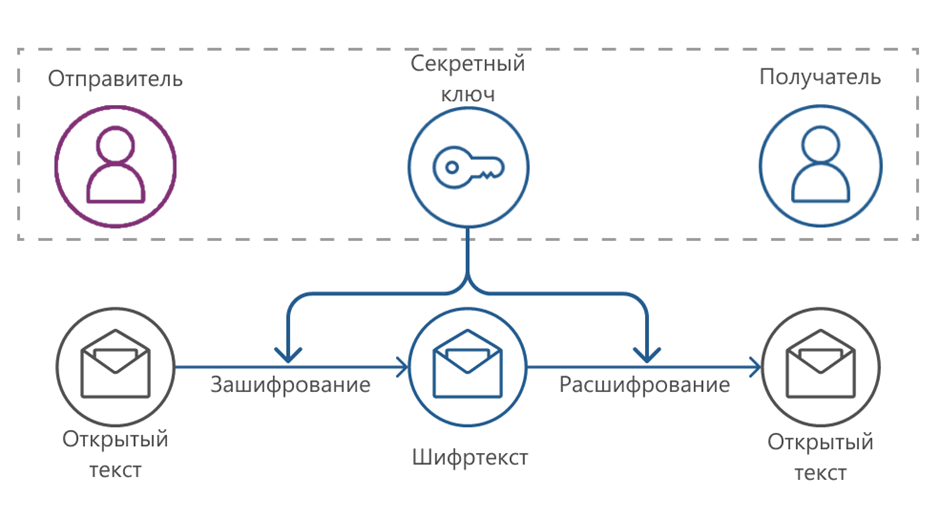

Рисунок 1

## Блочные шифры и сеть Фейстеля

- Блочные шифры обрабатывают данные фиксированными блоками.
- В основе многих современных алгоритмов лежит **сеть Фейстеля**.
- Для расшифрования используется тот же механизм, но подключи идут в обратном порядке рис. 2.

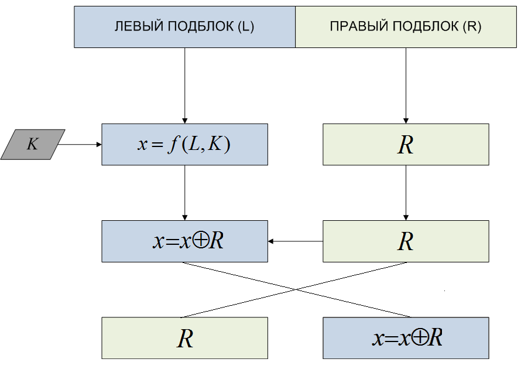

Рисунок 2

## Режимы работы блочных шифров

| Режим | Особенность | Замечание |
| --- | --- | --- |
| ECB | Блоки шифруются независимо | Одинаковые блоки дают одинаковый шифртекст |
| CBC | Каждый блок связан с предыдущим | Более безопасен, чем ECB |
| CFB | Блочный шифр работает как потоковый | Удобен для последовательной обработки |
| OFB | Гамма не зависит от данных | Ошибки не распространяются |
| CTR | Шифруется счётчик | Можно обрабатывать блоки параллельно |

## Поточные шифры

- Данные шифруются побитово или побайтово.
- Используется псевдослучайная гамма, зависящая от ключа.
- Шифр Вернама — теоретически абсолютно стойкий, но практически неудобный из-за длины и одноразовости ключа.

## Задачи криптографии

- **Конфиденциальность** — скрыть содержимое сообщения.
- **Целостность** — обнаружить изменения данных.
- **Аутентификация** — проверить подлинность источника.
- **Невозможность отказа от авторства** — подтвердить факт отправки.

# Заключение

## Главный вывод

- Шифрование — основа информационной безопасности.
- Без надёжного управления ключами даже сильный алгоритм не спасает систему.
- Симметричные, асимметричные, блочные и поточные схемы решают разные задачи и часто применяются вместе.